# Machine Learning Course Write-Up

Courtney D. Shelley

September 21, 2014

### Introduction

Six young health participants were asked to perform one set of 10 repetitions of the Unilateral Dumbbell Biceps Curl in five different fashions: exactly according to the specification (Class A), throwing the elbows to the front (Class B), lifting the dumbbell only halfway (Class C), lowering the dumbbell only halfway (Class D) and throwing the hips to the front (Class E).

Data sensors were placed on participants’ arm, forearm, belt, and dumbbell. Measurements were assessed in the x-, y-, and z- axes.

Read more: http://groupware.les.inf.puc-rio.br/har#literature#ixzz3DzMBhI3I

### Data

The data for this project come from this source: http://groupware.les.inf.puc-rio.br/har.

```r
library(caret); library(stats)


#### Training data set
fileURL <- "https://d396qusza40orc.cloudfront.net/predmachlearn/pml-training.csv"
download.file(fileURL, destfile = "trainingData.csv", method="curl")
training <- read.csv("trainingData.csv", header=TRUE)
dim(training)
```

```
## [1] 19622   160
```

```r
#### Test data set
fileURL2 <- "https://d396qusza40orc.cloudfront.net/predmachlearn/pml-testing.csv"
download.file(fileURL2, destfile = "testingData.csv", method="curl")
testing <- read.csv("testingData.csv", header =TRUE)
dim(testing)
```

```
## [1]  20 160
```

```r
set.seed(12345)
inTrain <- createDataPartition(y=training$classe, p=0.7, list=FALSE)
model<-training[inTrain,]
x.val<-training[-inTrain,]
dim(model); dim(x.val)
```

```
## [1] 13737   160
```

```
## [1] 5885  160
```

The training data set consists of 19,622 observations on 160 variables. The testing set consists of 20 observations on 160 variables. Training data was split into a model-building set and a cross-validation set to test the model prior to deployment on the testing set. 70% of training observations were randomly assigned to the model category (13737 observations) and 30% of training observations were randomly assigned to the cross-validating set (5885 observations).

## Model Creation

### Isolation of important variables

Due to the high number of available predictor variables, Principle Component Analysis (PCA) was used to isolate the most influential predictors. Data was first reduced to 48 predictor variables relating to gyros, acceleration, roll, pitch, yaw, and magnent and processed columns of variation, standard deviation, total, max, and min were omitted.

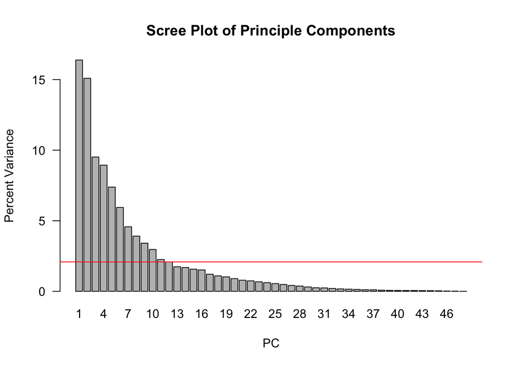

```r
#### Identify important predictor variables by name
gyros<-unique(grep("^gyros_", names(model), value=TRUE))   ## Retain only columns beginning in gyros_
accel<-unique(grep("^accel_", names(model), value=TRUE))   ## Retain only columns beginning in accel_
roll<-unique(grep("^roll_", names(model), value=TRUE))     ## Retain only columns beginning in roll_
pitch<-unique(grep("^pitch_", names(model), value=TRUE))   ## Retain only columns beginning in pitch_
yaw<-unique(grep("^yaw_", names(model), value=TRUE))       ## Retain only columns beginning in yaw_
magnet<-unique(grep("^magnet_", names(model), value=TRUE)) ## Retain only columns beginning in magnet_
greps<-c(gyros, accel, roll, pitch, yaw, magnet)   ## Concatenate retained column names

data<-model[, greps]      ##Subset model to only columns contained in greps and

#### Identify important predictor variables by Principle Component Analysis
######## I got this from http://strata.uga.edu/6370/lecturenotes/principalComponents.html
data.pca <- prcomp(data, retx=TRUE, center=TRUE, scale=TRUE)
sd <- data.pca$sdev
loadings <- data.pca$rotation         # indicate positive correlations between variables and PCs
rownames(loadings) <- colnames(data)
scores <- data.pca$x

         ### Scree Plot of PCs to determine which to retain ###
var <- sd^2
var.percent <- var/sum(var) *100
barplot(var.percent, xlab="PC", ylab="Percent Variance", main="Scree Plot of Principle Components",
        names.arg=1:length(var.percent), las=1,
        ylim=c(0,max(var.percent)), col="gray")
abline(h=1/ncol(data)*100, col="red")     # Retain PCs above this line
```

```r
var.percent[1:11]
```

```
##  [1] 16.384 15.087  9.513  8.937  7.385  5.940  4.572  3.910  3.411  2.964
## [11]  2.252
```

```r
sum(var.percent[1:11])       # Retained PCs explain 80% of explained variance
```

```
## [1] 80.36
```

### Model Build: Random Forest Classification

```r
library(randomForest)
###### First time through course I tried Classification Tree.  Accuracy of 0.505 and I scored 8/20 on testing set.

data<-model[, c(greps, "classe")]             #Training subset with answers
cross.validate<-x.val[, c(greps, "classe")]   #Cross Validate subset with answer
test<-testing[,c(greps,"problem_id")]         #Testing subset with answers

modFit<-randomForest(classe ~., data=data, ntree=500)
modFit     # Error rate of 0.51%
```

```
##
## Call:
##  randomForest(formula = classe ~ ., data = data, ntree = 500)
##                Type of random forest: classification
##                      Number of trees: 500
## No. of variables tried at each split: 6
##
##         OOB estimate of  error rate: 0.52%
## Confusion matrix:
##      A    B    C    D    E class.error
## A 3904    1    0    0    1    0.000512
## B   11 2643    4    0    0    0.005643
## C    0   16 2376    4    0    0.008347
## D    0    0   23 2227    2    0.011101
## E    0    0    2    7 2516    0.003564
```

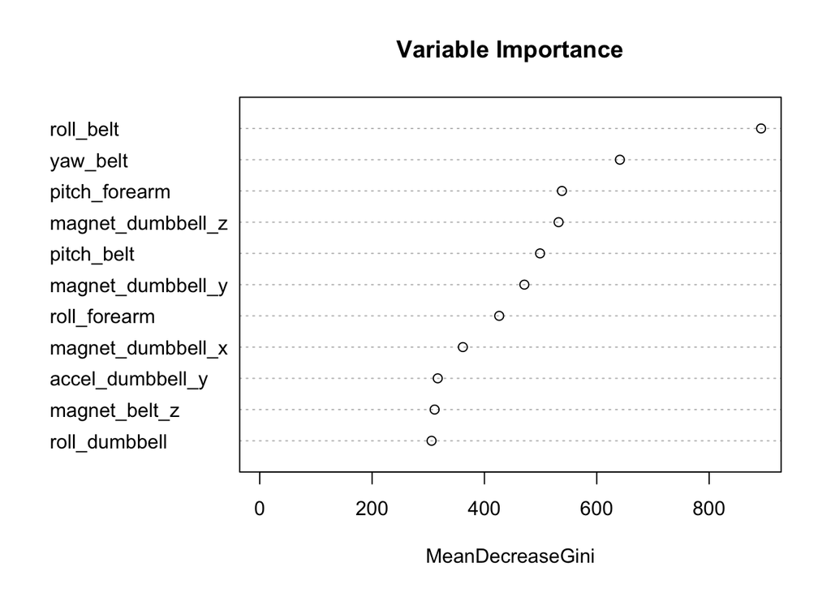

```r
varImpPlot(modFit, sort=TRUE, n.var=11, main="Variable Importance")
```

### Model Test by Cross Validation

```r
X.Val<-predict(modFit, newdata=x.val, type="response")
x.valRight<-X.Val==x.val$classe
table(x.valRight, x.val$classe)
```

```
##
## x.valRight    A    B    C    D    E
##      FALSE    1   14   14   14    4
##      TRUE  1673 1125 1012  950 1078
```

### Predictions on Test Data

```r
predict<-predict(modFit, newdata=test, type="response")
predictRight<-predict==test$problem_id
table(predict, test$problem_id)
```

```
##
## predict 1 2 3 4 5 6 7 8 9 10 11 12 13 14 15 16 17 18 19 20
##       A 0 1 0 1 1 0 0 0 1  1  0  0  0  1  0  0  1  0  0  0
##       B 1 0 1 0 0 0 0 1 0  0  1  0  1  0  0  0  0  1  1  1
##       C 0 0 0 0 0 0 0 0 0  0  0  1  0  0  0  0  0  0  0  0
##       D 0 0 0 0 0 0 1 0 0  0  0  0  0  0  0  0  0  0  0  0
##       E 0 0 0 0 0 1 0 0 0  0  0  0  0  0  1  1  0  0  0  0
```

### Submission

```r
pml_write_files = function(x) {
    n = length(x)
    for(i in 1:n){
      filename = paste0("problem_id_", i, ".txt")
      write.table(x[i], file=filename,quote=FALSE, row.names=FALSE,col.names=FALSE)
    }
  }

pml_write_files(predict)
```